# student_performance_factors_cleaning

1. Import Data
2. Explore Data
3. Missing Values, Duplicates, and Standardization of Column Names
4. Normality & Outlier Check  
   (1) Anderson-Darling Test for Normality  
   (2) Visualize Distributions (Histograms & Boxplots)  
   (3) Apply Box-Cox Transformation for Normalization  
   (4) Recheck Normality (Post-Transformation)
- Preliminary: Variable Types and Encoding Approach for Steps 5–7
5. Encoding Binary Variables
6. Encoding Ordinal Variables
7. Standardizing Numerical Features

### 1. Import data

https://www.kaggle.com/datasets/lainguyn123/student-performance-factors/data

```python
#read data
df_new = pd.read_csv(r"C:\Users\frida\Downloads\StudentPerformanceFactors.csv")
df_new.head(2)
```

|  | Hours_Studied | Attendance | Parental_Involvement | Access_to_Resources | Extracurricular_Activities | Sleep_Hours | Previous_Scores | Motivation_Level | Internet_Access | Tutoring_Sessions | Family_Income | Teacher_Quality | School_Type | Peer_Influence | Physical_Activity | Learning_Disabilities | Parental_Education_Level | Distance_from_Home | Gender | Exam_Score |
| --- | --- | --- | --- | --- | --- | --- | --- | --- | --- | --- | --- | --- | --- | --- | --- | --- | --- | --- | --- | --- |
| 0 | 23 | 84 | Low | High | No | 7 | 73 | Low | Yes | 0 | Low | Medium | Public | Positive | 3 | No | High School | Near | Male | 67 |
| 1 | 19 | 64 | Low | Medium | No | 8 | 59 | Low | Yes | 2 | Medium | Medium | Public | Negative | 4 | No | College | Moderate | Female | 61 |

### 2. Explore data

```python
df_new.info()
```

```
<class 'pandas.core.frame.DataFrame'>
RangeIndex: 6607 entries, 0 to 6606
Data columns (total 20 columns):
 #   Column                      Non-Null Count  Dtype
---  ------                      --------------  -----
 0   Hours_Studied               6607 non-null   int64
 1   Attendance                  6607 non-null   int64
 2   Parental_Involvement        6607 non-null   object
 3   Access_to_Resources         6607 non-null   object
 4   Extracurricular_Activities  6607 non-null   object
 5   Sleep_Hours                 6607 non-null   int64
 6   Previous_Scores             6607 non-null   int64
 7   Motivation_Level            6607 non-null   object
 8   Internet_Access             6607 non-null   object
 9   Tutoring_Sessions           6607 non-null   int64
 10  Family_Income               6607 non-null   object
 11  Teacher_Quality             6529 non-null   object
 12  School_Type                 6607 non-null   object
 13  Peer_Influence              6607 non-null   object
 14  Physical_Activity           6607 non-null   int64
 15  Learning_Disabilities       6607 non-null   object
 16  Parental_Education_Level    6517 non-null   object
 17  Distance_from_Home          6540 non-null   object
 18  Gender                      6607 non-null   object
 19  Exam_Score                  6607 non-null   int64
dtypes: int64(7), object(13)
memory usage: 1.0+ MB
```

```python
df_new.describe().round(2)
```

|  | Hours_Studied | Attendance | Sleep_Hours | Previous_Scores | Tutoring_Sessions | Physical_Activity | Exam_Score |
| --- | --- | --- | --- | --- | --- | --- | --- |
| count | 6607.00 | 6607.00 | 6607.00 | 6607.00 | 6607.00 | 6607.00 | 6607.00 |
| mean | 19.98 | 79.98 | 7.03 | 75.07 | 1.49 | 2.97 | 67.24 |
| std | 5.99 | 11.55 | 1.47 | 14.40 | 1.23 | 1.03 | 3.89 |
| min | 1.00 | 60.00 | 4.00 | 50.00 | 0.00 | 0.00 | 55.00 |
| 25% | 16.00 | 70.00 | 6.00 | 63.00 | 1.00 | 2.00 | 65.00 |
| 50% | 20.00 | 80.00 | 7.00 | 75.00 | 1.00 | 3.00 | 67.00 |
| 75% | 24.00 | 90.00 | 8.00 | 88.00 | 2.00 | 4.00 | 69.00 |
| max | 44.00 | 100.00 | 10.00 | 100.00 | 8.00 | 6.00 | 101.00 |

### 3. Missing Values, Duplicates, and Standardization of Column Names

```python
df_new.isna().sum()
```

```
Hours_Studied                  0
Attendance                     0
Parental_Involvement           0
Access_to_Resources            0
Extracurricular_Activities     0
Sleep_Hours                    0
Previous_Scores                0
Motivation_Level               0
Internet_Access                0
Tutoring_Sessions              0
Family_Income                  0
Teacher_Quality               78
School_Type                    0
Peer_Influence                 0
Physical_Activity              0
Learning_Disabilities          0
Parental_Education_Level      90
Distance_from_Home            67
Gender                         0
Exam_Score                     0
dtype: int64
```

```python
# check columns with missing values

print(df_new["Teacher_Quality"].value_counts())
print(df_new["Parental_Education_Level"].value_counts())
print(df_new["Distance_from_Home"].value_counts())
```

```
Teacher_Quality
Medium    3925
High      1947
Low        657
Name: count, dtype: int64
Parental_Education_Level
High School     3223
College         1989
Postgraduate    1305
Name: count, dtype: int64
Distance_from_Home
Near        3884
Moderate    1998
Far          658
Name: count, dtype: int64
```

```python
# Modes for each column
mode_teacher_quality = df_new["Teacher_Quality"].mode()
print("Mode Teacher Quality:", mode_teacher_quality)

mode_parent_ed = df_new["Parental_Education_Level"].mode()
print("Mode Parental Education Level:", mode_parent_ed)

mode_distance_home = df_new["Distance_from_Home"].mode()
print("Mode Distance from Home:", mode_distance_home)
```

```
Mode Teacher Quality: 0    Medium
Name: Teacher_Quality, dtype: object
Mode Parental Education Level: 0    High School
Name: Parental_Education_Level, dtype: object
Mode Distance from Home: 0    Near
Name: Distance_from_Home, dtype: object
```

```python
# Fill missing values in the "Teacher_Quality" column with its mode
df_new["Teacher_Quality"] = df_new["Teacher_Quality"].fillna(mode_teacher_quality[0])

# Fill missing values in the "Parental_Education_Level" column with its mode
df_new["Parental_Education_Level"] = df_new["Parental_Education_Level"].fillna(mode_parent_ed[0])

# Fill missing values in the "Distance_from_Home" column with its mode
df_new["Distance_from_Home"] = df_new["Distance_from_Home"].fillna(mode_distance_home[0])

df_new.isna().sum()
```

```
Hours_Studied                 0
Attendance                    0
Parental_Involvement          0
Access_to_Resources           0
Extracurricular_Activities    0
Sleep_Hours                   0
Previous_Scores               0
Motivation_Level              0
Internet_Access               0
Tutoring_Sessions             0
Family_Income                 0
Teacher_Quality               0
School_Type                   0
Peer_Influence                0
Physical_Activity             0
Learning_Disabilities         0
Parental_Education_Level      0
Distance_from_Home            0
Gender                        0
Exam_Score                    0
dtype: int64
```

```python
# Check for duplicates
df_new.duplicated().sum()
```

```
0
```

```python
#capitalize the first letter of each column name and convert all other letters to lowercase
df_new.rename(columns = lambda x: x.capitalize(), inplace = True)
df_new.head(1)
```

|  | Hours_studied | Attendance | Parental_involvement | Access_to_resources | Extracurricular_activities | Sleep_hours | Previous_scores | Motivation_level | Internet_access | Tutoring_sessions | Family_income | Teacher_quality | School_type | Peer_influence | Physical_activity | Learning_disabilities | Parental_education_level | Distance_from_home | Gender | Exam_score |
| --- | --- | --- | --- | --- | --- | --- | --- | --- | --- | --- | --- | --- | --- | --- | --- | --- | --- | --- | --- | --- |
| 0 | 23 | 84 | Low | High | No | 7 | 73 | Low | Yes | 0 | Low | Medium | Public | Positive | 3 | No | High School | Near | Male | 67 |

### 4. Normality and Outlier check

#### (1) Anderson-Darling Test for Normality

```python
import scipy.stats as stats

columns_normality = ["Hours_studied", "Attendance", "Sleep_hours", "Previous_scores", "Exam_score"]

# Loop through each column and perform Anderson-Darling test for normality
for column in columns_normality:
    result = stats.anderson(df_new[column], dist="norm")

    print(f"Anderson-Darling test result for {column}:")
    print("Statistic:", result.statistic)
    print("Critical values:", result.critical_values)
    print("Significance levels:", result.significance_level)
    print()
```

```
Anderson-Darling test result for Hours_studied:
Statistic: 7.502903459651861
Critical values: [0.576 0.656 0.787 0.917 1.091]
Significance levels: [15.  10.   5.   2.5  1. ]

Anderson-Darling test result for Attendance:
Statistic: 74.53201561707738
Critical values: [0.576 0.656 0.787 0.917 1.091]
Significance levels: [15.  10.   5.   2.5  1. ]

Anderson-Darling test result for Sleep_hours:
Statistic: 124.92077470714685
Critical values: [0.576 0.656 0.787 0.917 1.091]
Significance levels: [15.  10.   5.   2.5  1. ]

Anderson-Darling test result for Previous_scores:
Statistic: 72.78603939224013
Critical values: [0.576 0.656 0.787 0.917 1.091]
Significance levels: [15.  10.   5.   2.5  1. ]

Anderson-Darling test result for Exam_score:
Statistic: 51.25168473553367
Critical values: [0.576 0.656 0.787 0.917 1.091]
Significance levels: [15.  10.   5.   2.5  1. ]
```

#### (2) Visualize Distributions (Histograms & Boxplots)

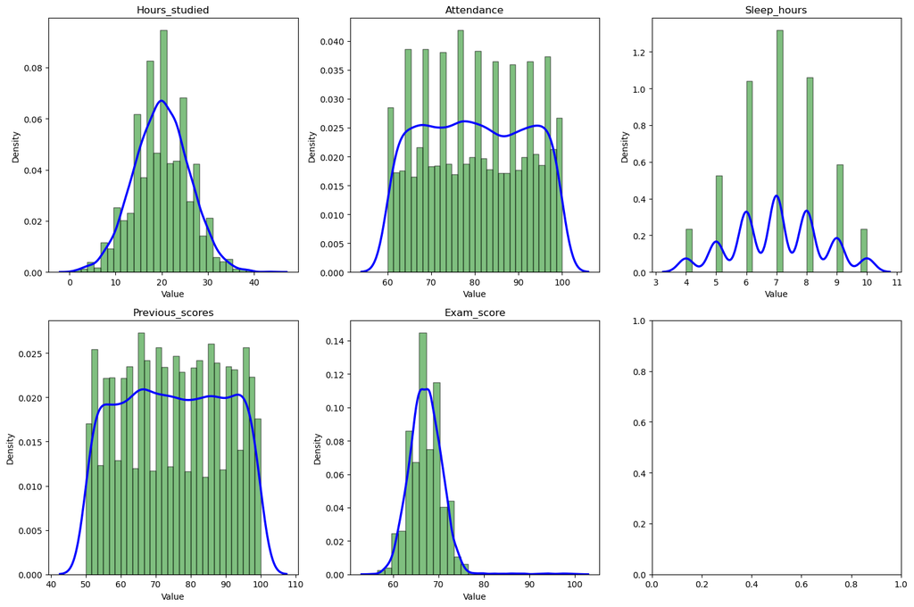

```python
# When you want to create multiple histograms
# List of columns to create histograms for
colums_to_plot = ["Hours_studied", "Attendance", "Sleep_hours", "Previous_scores", "Exam_score"]

# Create subplots based on the number of values in colums_to_plot

import matplotlib.pyplot as plt
import seaborn as sns

columns_to_plot = ["Hours_studied", "Attendance", "Sleep_hours", "Previous_scores", "Exam_score"]

fig, axes = plt.subplots(nrows=2, ncols=3, figsize=(15, 10))
axes = axes.flatten()  # Flatten the 2D array of axes for easy iteration

# Create histograms and overlay KDE for each column
for ax, col in zip(axes, columns_to_plot):
    if col in df_new.columns:
        # Plot the histogram with density normalization
        ax.hist(df_new[col], bins=30, alpha=0.5, color="green", edgecolor="black", density=True)

        # Overlay KDE (density curve)
        sns.kdeplot(df_new[col], ax=ax, color="blue", linewidth=2.5)

        ax.set_title(col)
        ax.set_xlabel("Value")
        ax.set_ylabel("Density")
    else:
        ax.set_title(f"{col} not found")
        ax.axis("off")

# Adjust layout to prevent overlap
plt.tight_layout()
plt.show()
```

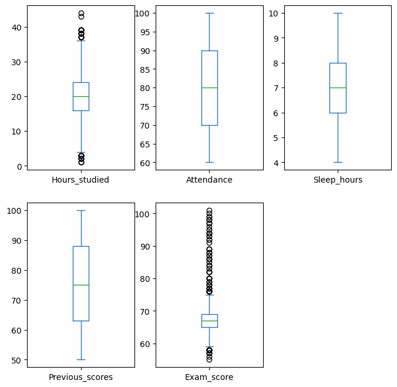

```python
columns_to_plot = ["Hours_studied", "Attendance", "Sleep_hours", "Previous_scores", "Exam_score"]

df_new[columns_to_plot].plot(kind="box", subplots=True, layout=(2, 3), sharex=False, sharey=False, figsize=(8, 8))
plt.show()
```

#### (3) Apply Box-Cox Transformation for Normalization

```python
from scipy import stats

# List of columns to transform
columns_to_transform = ["Hours_studied", "Attendance", "Sleep_hours", "Previous_scores", "Exam_score"]

# Loop through the columns and apply Box-Cox transformation
for col in columns_to_transform:
    df2[col + "_boxcox"], fitted_lambda = stats.boxcox(df2[col])

df2.head(2)
```

|  | Hours_studied | Attendance | Parental_involvement | Access_to_resources | Extracurricular_activities | Sleep_hours | Previous_scores | Motivation_level | Internet_access | Tutoring_sessions | ... | Learning_disabilities | Parental_education_level | Distance_from_home | Gender | Exam_score | Hours_studied_boxcox | Attendance_boxcox | Sleep_hours_boxcox | Previous_scores_boxcox | Exam_score_boxcox |
| --- | --- | --- | --- | --- | --- | --- | --- | --- | --- | --- | --- | --- | --- | --- | --- | --- | --- | --- | --- | --- | --- |
| 0 | 23 | 84 | Low | High | No | 7 | 73 | Low | Yes | 0 | ... | No | High School | Near | Male | 67 | 20.374146 | 29.971858 | 5.791028 | 34.140668 | 53.103451 |
| 1 | 19 | 64 | Low | Medium | No | 8 | 59 | Low | Yes | 2 | ... | No | College | Moderate | Female | 61 | 16.765520 | 24.554137 | 6.736213 | 28.776013 | 48.563104 |

2 rows × 25 columns

#### (4) Recheck Normality (Post-Transformation)

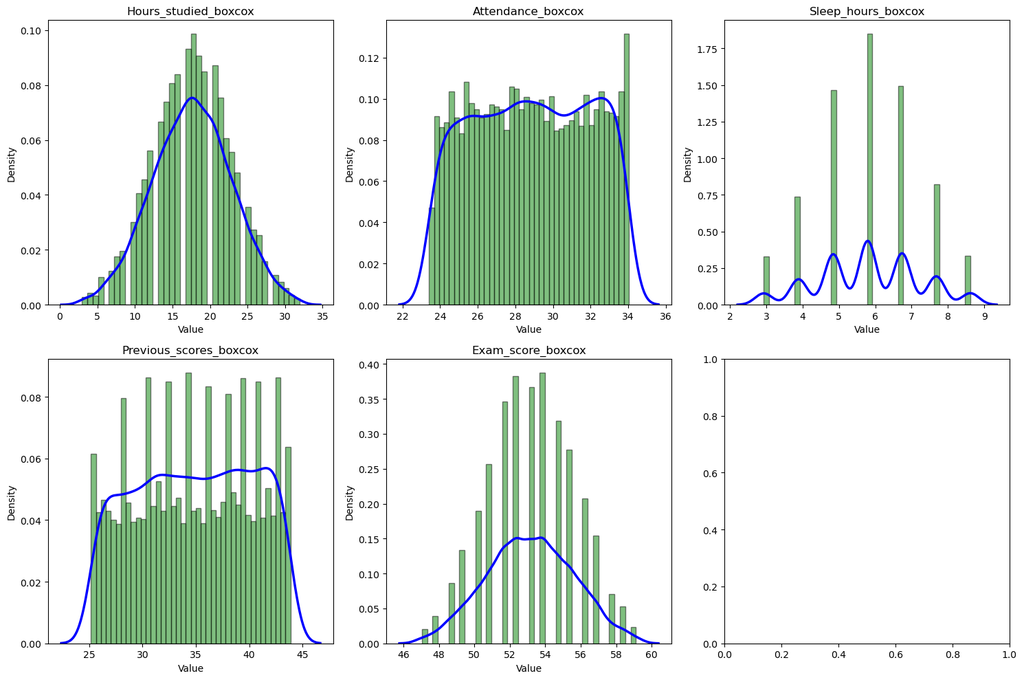

```python
# Create subplots based on the number of values in colums_to_plot

import matplotlib.pyplot as plt
import seaborn as sns

boxcox_to_plot = ["Hours_studied_boxcox", "Attendance_boxcox", "Sleep_hours_boxcox", "Previous_scores_boxcox", "Exam_score_boxcox"]

fig, axes = plt.subplots(nrows=2, ncols=3, figsize=(15, 10))
axes = axes.flatten()  # Flatten the 2D array of axes for easy iteration

# Create histograms and overlay KDE for each column
for ax, col in zip(axes, boxcox_to_plot):
    if col in df2.columns:
        # Plot the histogram with density normalization
        ax.hist(df2[col], bins=40, alpha=0.5, color="green", edgecolor="black", density=True)

        # Overlay KDE (density curve)
        sns.kdeplot(df2[col], ax=ax, color="blue", linewidth=2.5)

        ax.set_title(col)
        ax.set_xlabel("Value")
        ax.set_ylabel("Density")
    else:
        ax.set_title(f"{col} not found")
        ax.axis("off")

# Adjust layout to prevent overlap
plt.tight_layout()
plt.show()
```

### Variable Types and Encoding Approach for Steps 5–7

1.Categorical variable

> 1)Binary: e.g., Yes/No - Use Label Encoding :

> > (1)"Extracurricular_activities", "Internet_access", "Learning_disabilities"  
> > (2)"Gender", "School_type"

> 2)Ordinal w/o equal intervals: e.g., Low, Medium, High - Use Label Encoding : "Parental_involvement", "Motivation_level" "Access_to_resources","Family_income", "Teacher_quality","Parental_education_level","Distance_from_home", "Peer_influence"

> 3)Nominal: e.g., Red, Blue, Green - Use One-Hot Encoding

2.Numerical Variables

> (1) standardized or normalized: "Hours_studied_boxcox", "Attendance_boxcox", "Sleep_hours_boxcox", "Previous_scores_boxcox", "Exam_score_boxcox"

### 5.Encoding Binary Variables

```python
#binalry variables
binary_vars = ["Extracurricular_activities", "Internet_access", "Learning_disabilities", "Gender", "School_type"]

for var in binary_vars:
    freq_table = df_boxcox[var].value_counts().sort_index()
    print(f"Frequency Analysis for {var}:\n{freq_table}\n")
    print()
```

```
Frequency Analysis for Extracurricular_activities:
Extracurricular_activities
No     2617
Yes    3856
Name: count, dtype: int64


Frequency Analysis for Internet_access:
Internet_access
No      486
Yes    5987
Name: count, dtype: int64


Frequency Analysis for Learning_disabilities:
Learning_disabilities
No     5797
Yes     676
Name: count, dtype: int64


Frequency Analysis for Gender:
Gender
Female    2731
Male      3742
Name: count, dtype: int64


Frequency Analysis for School_type:
School_type
Private    1968
Public     4505
Name: count, dtype: int64
```

```python
#binary variables (yes/no)
from sklearn.preprocessing import LabelEncoder
label_encoder = LabelEncoder()

binary_vars = ["Extracurricular_activities", "Internet_access", "Learning_disabilities"]
for var in binary_vars:
    df_boxcox[var] = label_encoder.fit_transform(df_boxcox[var])

df_boxcox.head(2)
```

|  | Parental_involvement | Access_to_resources | Extracurricular_activities | Motivation_level | Internet_access | Tutoring_sessions | Family_income | Teacher_quality | School_type | Peer_influence | Physical_activity | Learning_disabilities | Parental_education_level | Distance_from_home | Gender | Hours_studied_boxcox | Attendance_boxcox | Sleep_hours_boxcox | Previous_scores_boxcox | Exam_score_boxcox |
| --- | --- | --- | --- | --- | --- | --- | --- | --- | --- | --- | --- | --- | --- | --- | --- | --- | --- | --- | --- | --- |
| 0 | Low | High | 0 | Low | 1 | 0 | Low | Medium | Public | Positive | 3 | 0 | High School | Near | Male | 20.374146 | 29.971858 | 5.791028 | 34.140668 | 53.103451 |
| 1 | Low | Medium | 0 | Low | 1 | 2 | Medium | Medium | Public | Negative | 4 | 0 | College | Moderate | Female | 16.765520 | 24.554137 | 6.736213 | 28.776013 | 48.563104 |

```python
import pandas as pd
from sklearn.preprocessing import LabelEncoder

# Initialize label encoder instances
gender_encoder = LabelEncoder()
school_type_encoder = LabelEncoder()

# Gender
df_boxcox["Gender_encoded"] = gender_encoder.fit_transform(df_boxcox["Gender"])
gender_mapping = dict(zip(gender_encoder.classes_, range(len(gender_encoder.classes_))))
print("Mapping for gender:", gender_mapping)

# School_type
df_boxcox["School_type_encoded"] = school_type_encoder.fit_transform(df_boxcox["School_type"])
school_type_mapping = dict(zip(school_type_encoder.classes_, range(len(school_type_encoder.classes_))))
print("Mapping for school type:", school_type_mapping)
```

```
Mapping for gender: {'Female': 0, 'Male': 1}
Mapping for school type: {'Private': 0, 'Public': 1}
```

```python
df_boxcox.head(2)
```

|  | Parental_involvement | Access_to_resources | Extracurricular_activities | Motivation_level | Internet_access | Tutoring_sessions | Family_income | Teacher_quality | School_type | Peer_influence | ... | Parental_education_level | Distance_from_home | Gender | Hours_studied_boxcox | Attendance_boxcox | Sleep_hours_boxcox | Previous_scores_boxcox | Exam_score_boxcox | Gender_encoded | School_type_encoded |
| --- | --- | --- | --- | --- | --- | --- | --- | --- | --- | --- | --- | --- | --- | --- | --- | --- | --- | --- | --- | --- | --- |
| 0 | Low | High | 0 | Low | 1 | 0 | Low | Medium | Public | Positive | ... | High School | Near | Male | 20.374146 | 29.971858 | 5.791028 | 34.140668 | 53.103451 | 1 | 1 |
| 1 | Low | Medium | 0 | Low | 1 | 2 | Medium | Medium | Public | Negative | ... | College | Moderate | Female | 16.765520 | 24.554137 | 6.736213 | 28.776013 | 48.563104 | 0 | 1 |

2 rows × 22 columns

### 6. Encoding and Conversion of Ordinary Variables

```python
# Ordinal variables
ordinal_vars = ["Parental_involvement", "Motivation_level", "Access_to_resources",
                "Family_income", "Teacher_quality", "Parental_education_level",
                "Distance_from_home", "Peer_influence"]

# Frequency analysis for each ordinal variable
for var in ordinal_vars:
    freq_table = df_boxcox[var].value_counts().sort_index()
    print(f"Frequency Analysis for {var}:\n{freq_table}\n")
    print()
```

```
Frequency Analysis for Parental_involvement:
Parental_involvement
High      1857
Low       1311
Medium    3305
Name: count, dtype: int64


Frequency Analysis for Motivation_level:
Motivation_level
High      1285
Low       1897
Medium    3291
Name: count, dtype: int64


Frequency Analysis for Access_to_resources:
Access_to_resources
High      1927
Low       1284
Medium    3262
Name: count, dtype: int64


Frequency Analysis for Family_income:
Family_income
High      1242
Low       2611
Medium    2620
Name: count, dtype: int64


Frequency Analysis for Teacher_quality:
Teacher_quality
High      1909
Low        643
Medium    3921
Name: count, dtype: int64


Frequency Analysis for Parental_education_level:
Parental_education_level
College         1950
High School     3243
Postgraduate    1280
Name: count, dtype: int64


Frequency Analysis for Distance_from_home:
Distance_from_home
Far          636
Moderate    1958
Near        3879
Name: count, dtype: int64


Frequency Analysis for Peer_influence:
Peer_influence
Negative    1346
Neutral     2541
Positive    2586
Name: count, dtype: int64
```

```python
import pandas as pd
from sklearn.preprocessing import LabelEncoder

# Group 1: low, medium, high
ordinal_vars = ["Parental_involvement", "Motivation_level", "Access_to_resources",
                "Family_income", "Teacher_quality"]

# Define the order of categories for all variables
category_order = ["Low", "Medium", "High"]

# Apply label encoding for each variable
encoder = LabelEncoder()

for var in ordinal_vars:
    # Convert each column to a categorical type with the defined order
    df_boxcox[var] = pd.Categorical(df_boxcox[var], categories=category_order, ordered=True)

    # Fit and transform the encoder for each variable separately
    df_boxcox[f'{var}_encoded'] = encoder.fit_transform(df_boxcox[var])
```

```python
df_boxcox.head(3)
```

|  | Parental_involvement | Access_to_resources | Extracurricular_activities | Motivation_level | Internet_access | Tutoring_sessions | Family_income | Teacher_quality | School_type | Peer_influence | ... | Sleep_hours_boxcox | Previous_scores_boxcox | Exam_score_boxcox | Gender_encoded | School_type_encoded | Parental_involvement_encoded | Motivation_level_encoded | Access_to_resources_encoded | Family_income_encoded | Teacher_quality_encoded |
| --- | --- | --- | --- | --- | --- | --- | --- | --- | --- | --- | --- | --- | --- | --- | --- | --- | --- | --- | --- | --- | --- |
| 0 | Low | High | 0 | Low | 1 | 0 | Low | Medium | Public | Positive | ... | 5.791028 | 34.140668 | 53.103451 | 1 | 1 | 1 | 1 | 0 | 1 | 2 |
| 1 | Low | Medium | 0 | Low | 1 | 2 | Medium | Medium | Public | Negative | ... | 6.736213 | 28.776013 | 48.563104 | 0 | 1 | 1 | 1 | 2 | 2 | 2 |
| 2 | Medium | Medium | 1 | Medium | 1 | 2 | Medium | Medium | Public | Neutral | ... | 5.791028 | 40.703745 | 58.366305 | 1 | 1 | 2 | 2 | 2 | 2 | 2 |

3 rows × 27 columns

```python
# Group 2: 'Parental_education_level', 'Distance_from_home', 'Peer_influence'

# education_order = ["High School", "College", "Postgraduate"]
# distance_order = ["Near", "Moderate", "Far"]
# influence_order = ["Negative", "Neutral", "Positive"]

# Parental_education_level
df_boxcox["Parental_education_level"] = df_boxcox["Parental_education_level"].replace({
    "High School":0,
    "College":1,
    "Postgraduate":2
})

# Distance_from_home (ordinal encoding)
df_boxcox["Distance_from_home"] = df_boxcox["Distance_from_home"].replace({
    "Near":0,
    "Moderate":1,
    "Far":2
})


# Peer_influence (ordinal encoding)
df_boxcox["Peer_influence"] = df_boxcox["Peer_influence"].replace({
    "Negative":0,
    "Neutral":1,
    "Positive":2
})
```

```python
df_new_boxcox = df_boxcox.drop(columns = ["Parental_involvement", "Access_to_resources", "Motivation_level", "Family_income", "Teacher_quality", "School_type", "Gender"])
```

```python
df_new_boxcox.head(3)
```

|  | Extracurricular_activities | Internet_access | Tutoring_sessions | Peer_influence | Physical_activity | Learning_disabilities | Parental_education_level | Distance_from_home | Hours_studied_boxcox | Attendance_boxcox | Sleep_hours_boxcox | Previous_scores_boxcox | Exam_score_boxcox | Gender_encoded | School_type_encoded | Parental_involvement_encoded | Motivation_level_encoded | Access_to_resources_encoded | Family_income_encoded | Teacher_quality_encoded |
| --- | --- | --- | --- | --- | --- | --- | --- | --- | --- | --- | --- | --- | --- | --- | --- | --- | --- | --- | --- | --- |
| 0 | 0 | 1 | 0 | 2 | 3 | 0 | 0 | 0 | 20.374146 | 29.971858 | 5.791028 | 34.140668 | 53.103451 | 1 | 1 | 1 | 1 | 0 | 1 | 2 |
| 1 | 0 | 1 | 2 | 0 | 4 | 0 | 1 | 1 | 16.765520 | 24.554137 | 6.736213 | 28.776013 | 48.563104 | 0 | 1 | 1 | 1 | 2 | 2 | 2 |
| 2 | 1 | 1 | 2 | 1 | 4 | 0 | 2 | 0 | 21.272830 | 33.530465 | 5.791028 | 40.703745 | 58.366305 | 1 | 1 | 2 | 2 | 2 | 2 | 2 |

```python
#clean the column names
columns_to_rename = ["Gender_encoded","School_type_encoded", "Parental_involvement_encoded", "Motivation_level_encoded",
    "Access_to_resources_encoded", "Family_income_encoded", "Teacher_quality_encoded"]

# Rename the columns by removing the '_encoded' suffix
df_boxcox_transformed = df_boxcox_transformed.rename(columns={col: col.replace('_encoded', '') for col in df_boxcox_transformed.columns if col in columns_to_rename})
```

```python
df_boxcox_transformed.head(1)
```

|  | Extracurricular_activities | Internet_access | Tutoring_sessions | Peer_influence | Physical_activity | Learning_disabilities | Parental_education_level | Distance_from_home | Hours_studied | Attendance | Sleep_hours | Previous_scores | Exam_score | Gender | School_type | Parental_involvement | Motivation_level | Access_to_resources | Family_income | Teacher_quality |
| --- | --- | --- | --- | --- | --- | --- | --- | --- | --- | --- | --- | --- | --- | --- | --- | --- | --- | --- | --- | --- |
| 0 | 0 | 1 | 0 | 2 | 3 | 0 | 0 | 0 | 20.374146 | 29.971858 | 5.791028 | 34.140668 | 53.103451 | 1 | 1 | 1 | 1 | 0 | 1 | 2 |

### 7. Standardizing Numerical Features

```python
from sklearn.preprocessing import StandardScaler

numerical_vars = ["Hours_studied","Attendance","Sleep_hours","Previous_scores","Exam_score"]

scaler = StandardScaler()
df_boxcox_transformed[numerical_vars] = scaler.fit_transform(df_boxcox_transformed[numerical_vars])
```

```python
df_boxcox_transformed.head(5)
```

|  | Extracurricular_activities | Internet_access | Tutoring_sessions | Peer_influence | Physical_activity | Learning_disabilities | Parental_education_level | Distance_from_home | Hours_studied | Attendance | Sleep_hours | Previous_scores | Exam_score | Gender | School_type | Parental_involvement | Motivation_level | Access_to_resources | Family_income | Teacher_quality |
| --- | --- | --- | --- | --- | --- | --- | --- | --- | --- | --- | --- | --- | --- | --- | --- | --- | --- | --- | --- | --- |
| 0 | 0 | 1 | 0 | 2 | 3 | 0 | 0 | 0 | 0.527037 | 0.368681 | -0.017616 | -0.123318 | -0.018328 | 1 | 1 | 1 | 1 | 0 | 1 | 2 |
| 1 | 0 | 1 | 2 | 0 | 4 | 0 | 1 | 1 | -0.163009 | -1.409589 | 0.661535 | -1.122545 | -1.877553 | 0 | 1 | 1 | 1 | 2 | 2 | 2 |
| 2 | 1 | 1 | 2 | 1 | 4 | 0 | 2 | 0 | 0.698884 | 1.536731 | -0.017616 | 1.099127 | 2.136755 | 1 | 1 | 2 | 2 | 2 | 2 | 2 |
| 3 | 1 | 1 | 1 | 0 | 4 | 0 | 0 | 1 | 1.554678 | 0.792175 | 0.661535 | 1.559088 | 1.214900 | 1 | 1 | 1 | 2 | 2 | 2 | 2 |
| 4 | 1 | 1 | 3 | 1 | 4 | 0 | 1 | 0 | -0.163009 | 1.042797 | -0.699497 | -0.688310 | 0.907040 | 0 | 1 | 2 | 2 | 2 | 2 | 0 |

```python
df_boxcox_transformed.isnull().sum()
```

```
Extracurricular_activities    0
Internet_access               0
Tutoring_sessions             0
Peer_influence                0
Physical_activity             0
Learning_disabilities         0
Parental_education_level      0
Distance_from_home            0
Hours_studied                 0
Attendance                    0
Sleep_hours                   0
Previous_scores               0
Exam_score                    0
Gender                        0
School_type                   0
Parental_involvement          0
Motivation_level              0
Access_to_resources           0
Family_income                 0
Teacher_quality               0
dtype: int64
```

```python
df_cleaned.head(3)
```

|  | Extracurricular_activities | Internet_access | Tutoring_sessions | Peer_influence | Physical_activity | Learning_disabilities | Parental_education_level | Distance_from_home | Hours_studied | Attendance | Sleep_hours | Previous_scores | Exam_score | Gender | School_type | Parental_involvement | Motivation_level | Access_to_resources | Family_income | Teacher_quality |
| --- | --- | --- | --- | --- | --- | --- | --- | --- | --- | --- | --- | --- | --- | --- | --- | --- | --- | --- | --- | --- |
| 0 | 0 | 1 | 0 | 2 | 3 | 0 | 0 | 0 | 0.527037 | 0.368681 | -0.017616 | -0.123318 | -0.018328 | 1 | 1 | 1 | 1 | 0 | 1 | 2 |
| 1 | 0 | 1 | 2 | 0 | 4 | 0 | 1 | 1 | -0.163009 | -1.409589 | 0.661535 | -1.122545 | -1.877553 | 0 | 1 | 1 | 1 | 2 | 2 | 2 |
| 2 | 1 | 1 | 2 | 1 | 4 | 0 | 2 | 0 | 0.698884 | 1.536731 | -0.017616 | 1.099127 | 2.136755 | 1 | 1 | 2 | 2 | 2 | 2 | 2 |